# Emission Analysis

Rishi Shanthan Bhagavatham

```r
library(ISLR2)
library(ggplot2)
library(MASS)
library(car)
library(class)
```

In case you need to write math expression, please use the quick tutorial as the reference: https://www1.cmc.edu/pages/faculty/aaksoy/latex/latexthree.html

# Question 1 [5 points]

Describe a situation or problem from your job, everyday life, current events, etc., for which a logistic regression model would be appropriate. List some (up to 5) predictors that you might use.

Please show your work.

```
Answer: Predicting whether a patient is at risk of developing a certain medical condition, such as diabetes, based on various predictors. Here are some potential predictors:
Body Mass Index (BMI): A measure of body fat based on height and weight.
Blood sugar levels: Fasting blood glucose levels, which may indicate prediabetes or diabetes.
Family history: Whether the patient has a family history of diabetes.
Physical activity: The level of physical activity or exercise habits of the patient.
Diet: The patient's dietary habits, such as consumption of sugary or high-carbohydrate foods.
```

# Question 2 [20 points]

In this problem, we will use the Naive Bayes algorithm to fit a spam filter by hand. This question does not involve any programming but only derivation and hand calculation. Spam filters are used in all email services to classify received emails as “Spam” or “Not Spam”. A simple approach involves maintaining a vocabulary of words that commonly occur in “Spam” emails and classifying an email as “Spam” if the number of words fromthe dictionary that are present in the email is over a certain threshold. We are given the vocabulary consists of 15 words

$$V = {\text{secret, offer, low, price,
valued, customer, today, dollar, million, sports, is, for, play,
healthy, pizza}}.$$

We will use $V_i$ to represent the $i$th word in $V$ . As our training dataset, we are also given 3 example spam messages,

- million dollar offer for today
- secret offer today
- secret is secret

and 4 example non-spam messages

- low price for valued customer
- play secret sports today
- sports is healthy
- low price pizza

Recall that the Naive Bayes classifier assumes the probability of an input depends on its input feature. The feature for each sample is defined as $x^{(i)}=[x^{(i)}_1, x^{(i)}_2,\cdots, x^{(i)}_p], i=1,\cdots,m$ and the class of the $i$th sample is $y^{(i)}$. In our case the length of the input vector is $p= 15$, which is equal to the number of words in the vocabulary $V$ (hint: recall that how did we define a dummy variable). Each entry $x^{(i)}_j$ is equal to the number of times word $V_j$ occurs in the $i$-th message.

1.[5 points] Calculate class prior $P(y = 0)$ and $P(y = 1)$ from the training data, where $y=0$ corresponds to spam messages, and $y=1$ corresponds to non-spam messages. Note that these class prior essentially corresponds to the frequency of each class in the training sample. Write down the predictor vectors for each spam and non-spam messages.

```
Answer: To calculate the class prior probabilities P(y=0) for spam messages and P(y=1) for non-spam messages from the training data, you need to divide the number of examples of each class by the total number of examples.
The predictor vectors for each spam and non-spam message are created by counting the occurrences of each word in the vocabulary in each message. Each position in the vector corresponds to a word in the vocabulary. If the word is present in the message, the corresponding position in the vector will be a 1 (or the count of occurrences if multiple occurrences are counted); if the word is not present, the position will be a 0.
P(y=0) (Spam messages) = 0.4286 (or approximately 3/7)
P(y=1) (Non-spam messages) = 0.5714 (or approximately 4/7)
The predictor vectors for each spam and non-spam message are as follows:
Spam Messages (Each row corresponds to a message):
[0, 1, 0, 0, 0, 0, 1, 1, 1, 0, 0, 1, 0, 0, 0]
[1, 1, 0, 0, 0, 0, 1, 0, 0, 0, 0, 0, 0, 0, 0]
[2, 0, 0, 0, 0, 0, 0, 0, 0, 0, 1, 0, 0, 0, 0]

Non-Spam Messages (Each row corresponds to a message):
[0, 0, 1, 1, 1, 1, 0, 0, 0, 0, 0, 1, 0, 0, 0]
[1, 0, 0, 0, 0, 0, 1, 0, 0, 1, 0, 0, 1, 0, 0]
[0, 0, 0, 0, 0, 0, 0, 0, 0, 1, 1, 0, 0, 1, 0]
[0, 0, 1, 1, 0, 0, 0, 0, 0, 0, 0, 0, 0, 0, 1]
Each vector represents the count of each word from the vocabulary in the corresponding message.
```

2. [15 points] In the Naive Bayes model, assuming the keywords are independent of each other (this is a simplification), the likelihood of a sentence with its feature vector $x$ given a class $c$ is given by
   $$P(x|y=c)=\prod_{i=1}^{15}P(x_i|y=c),
   c=\{0,1\}.$$

Given a test message “today is secret”, using the Naive Bayes classier to calculate the posterior and decide whether it is spam or not spam. Please show your work.

```
Answer: likelihood is given by  P(x|=c), prior is given by P(y=c)
Posterior Probabibilty is given by P(y = c|x) = P(x|y = c).P(y = c) / P(x)

Message : 'today is secret'

Calculating Likelihood:
1. for x = today
    1.1 y = 0(spam) : P(today|y=0) = number of 'today' in spam messages/number of total words in spam messages

    P(today|y=0) = (1+1+0)/(5+3+3) = 2/11

    1.2 similarly for y=1(non-spam) : (0+1+0+0)/(5+4+3+3) = 1/15
2. for x = is
    2.1 y = 0(spam) : P(is|y=0) = (0+0+1)/(5+3+3) = 1/11
    2.2 y = 1(non-spam) : P(is|y=1) = (0+0+1+0)/(5+4+3+3) = 1/15
3. for x = secret
    3.1 y = 0(spam) : P(secret|y=0) = (0+1+2)/(5+3+3) = 3/11
    3.2 y = 1(non-spam) : P(secret|y=1) = (0+1+0+0)/(5+4+3+3) =  1/15

calculating Posterior Probability:
From the first question ,we know that  P(y=0) = 3/7;P(y=1) = 4/7

1. For y=0(spam):
    P(y=0|x) = P(today|y=0).P(is|y=0).P(secret|y=0).P(y=0)
    P(y=0|x) = (2/11).(1/11).(3/11).(3/7)
    P(y=0|x) = 18/9317 = 0.0019
2. For y=1(non-spam):
    P(y=1|x) = P(today|y=1).P(is|y=1).P(secret|y=1).P(y=1)
    P(y=1|x) = (1/15).(1/15).(1/15).(4/7)
    P(y=1|x) = 0.00016
The Posterior value for y=0(spam) is greater than the Posterior value of y=1(non-spam). Therefore, the given test message ('today is secret) is a spam message.
```

# Question 3 [16 points]

The provided dataset is a subset of the public data from the 2022 EPA Automotive Trends Report. It will be used to study the effects of various vehicle characteristics on CO2 emissions. The dataset consists of a dataframe with 1703 observations with the following 7 variables:

- Model.Year: year the vehicle model was produced (quantitative)
- Type: vehicle type (qualitative)
- MPG: miles per gallon of fuel (quantitative)
- Weight: vehicle weight in lbs (quantitative)
- Horsepower: vehicle horsepower in HP (quantitative)
- Acceleration: acceleration time (from 0 to 60 mph) in seconds (quantitative)
- CO2: carbon dioxide emissions in g/mi (response variable)

(1).[3 points] Read the data, Fit a multiple linear regression model called model1 using CO2 as the response and all predicting variables. Using $\alpha=0.05$, which of the estimated coefficients that were statistically significant.

```r
data <- read.csv("emissions.csv")
model1 <- lm(CO2 ~ Model.Year + Type + MPG + Weight + Horsepower + Acceleration, data = data)
summary(model1)
```

```
##
## Call:
## lm(formula = CO2 ~ Model.Year + Type + MPG + Weight + Horsepower +
##     Acceleration, data = data)
##
## Residuals:
##     Min      1Q  Median      3Q     Max
## -49.969 -12.299  -4.040   6.126 242.173
##
## Coefficients:
##                Estimate Std. Error t value Pr(>|t|)
## (Intercept)   1.250e+03  2.983e+02   4.190 2.94e-05 ***
## Model.Year   -2.859e-01  1.525e-01  -1.875   0.0609 .
## TypeSUV      -1.594e+01  2.199e+00  -7.249 6.35e-13 ***
## TypeTruck    -1.802e+01  2.201e+00  -8.186 5.24e-16 ***
## TypeVan      -3.082e+01  2.397e+00 -12.854  < 2e-16 ***
## MPG          -1.749e+01  3.507e-01 -49.882  < 2e-16 ***
## Weight        4.978e-02  2.588e-03  19.235  < 2e-16 ***
## Horsepower   -3.460e-01  2.918e-02 -11.858  < 2e-16 ***
## Acceleration  1.333e+00  5.516e-01   2.417   0.0158 *
## ---
## Signif. codes:  0 '***' 0.001 '**' 0.01 '*' 0.05 '.' 0.1 ' ' 1
##
## Residual standard error: 23.3 on 1694 degrees of freedom
## Multiple R-squared:  0.9399,   Adjusted R-squared:  0.9396
## F-statistic:  3309 on 8 and 1694 DF,  p-value: < 2.2e-16
```

```
# Only Model.Year is statistically insignificant among all the coefficients.
```

(2).[2 points] Is the overall regression (model1) significant at an $\alpha$-level of $0.05$? Explain how you determined the answer.

```
Answer:  To determine if the overall regression model (model1) is significant at an α-level of 0.05, you should look at the F-statistic and its corresponding p-value from the model summary output in R.A model is considered to be statistically significant if the p-value of the F-statistic is less than the chosen α-level (in this case, 0.05). If it is, you can reject the null hypothesis and conclude that your model provides a better fit than an intercept-only model, indicating that at least one of the predictors is significantly related to the response variable
```

```r
summary_model1 <- summary(model1)
fstatistic <- summary_model1$fstatistic # The F-statistic and its degrees of freedom
p_value <- pf(fstatistic[1], fstatistic[2], fstatistic[3], lower.tail = FALSE) # Calculate the p-value using the F-statistic
if (p_value < 0.05) {
  print("The regression model is significant at an alpha level of 0.05.")
} else {
  print("The regression model is not significant at an alpha level of 0.05.")
}
```

```
## [1] "The regression model is significant at an alpha level of 0.05."
```

(3).[6 points] **Identifying Influential Data Points** Cook’s Distances

The basic idea behind the measure is to delete the observations one at a time, each time refitting the regression model on the remaining $n-1$ observations. Then, we compare the results using all $n$ observations to the results with the $i$th observation deleted to see how much influence the observation has on the analysis. Analyzed as such, we are able to assess the potential impact each data point has on the regression analysis. One of such a method is called `Cook's distance`. To learn more on Cook’s distance in R, see https://rpubs.com/DragonflyStats/Cooks-Distance.

Create a plot for the Cook’s Distances (use model1). Using a threshold of $1$, are there any outliers? If yes, which data points?

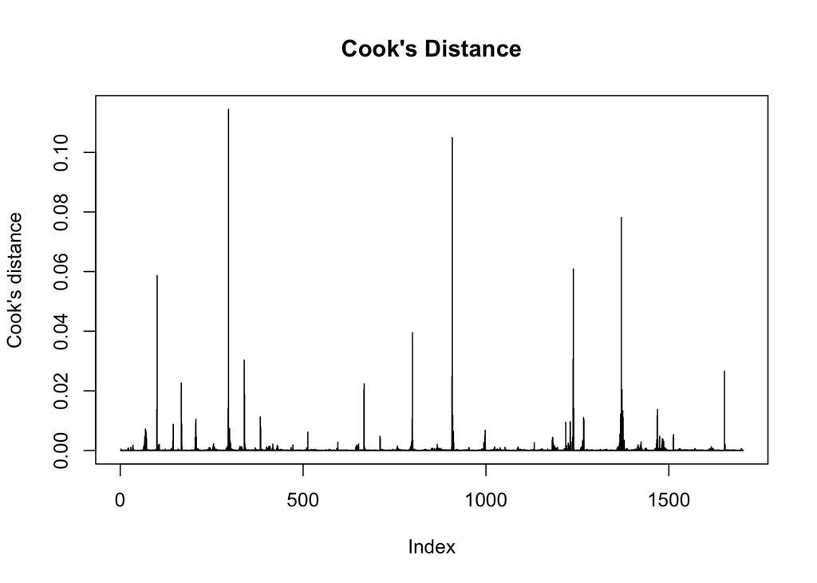

```
## integer(0)
```

```r
# Calculate Cook's Distances
cooks_d <- cooks.distance(model1)

# Plot Cook's Distances
plot(cooks_d, type="h", main="Cook's Distance", ylab="Cook's distance")
abline(h=1, col="red") # Add a horizontal line at threshold=1

# Adding labels for points above the threshold
identify(1:length(cooks_d), cooks_d, labels=ifelse(cooks_d > 1, names(cooks_d), ""), n=3, cex=0.8)
```

```r
# Identify Observations with Cook's Distance > 1
outliers <- which(cooks_d > 1)
if (length(outliers) > 0) {
  print(paste("Data points considered as outliers (Cook's Distance > 1):", paste(outliers, collapse=", ")))
} else {
  print("No outliers detected.\n")
}
```

```
## [1] "No outliers detected.\n"
```

(4).[5 points] **Detecting Multicollinearity Using Variance Inflation Factors (VIF)**

The effects that multicollinearity can have on our regression analyses and subsequent conclusions, how can we tell if multicollinearity is present in our data? A variance inflation factor exists for each of the predictors in a multiple regression model. For example, the variance inflation factor for the estimated regression coefficient $\beta_j$—denoted $VIF_j$ —is just the factor by which the variance of $\beta_j$ is “inflated” by the existence of correlation among the predictor variables in the model.

A VIF of $1$ means that there is no correlation among the $j$th predictor and the remaining predictor variables, and hence the variance of $\beta_j$ is not inflated at all. The general rule of thumb is that VIFs exceeding $4$ warrant further investigation, while VIFs exceeding $10$ are signs of serious multicollinearity requiring correction. For more information, see https://search.r-project.org/CRAN/refmans/usdm/html/vif.html.

Calculate the VIF of each predictor (use model1). Using a threshold of $\max(10, \frac{1}{1-R^2})$ what conclusions can you make regarding multicollinearity?

```r
# Calculate VIFs for 'model1'
vifs <- vif(model1)
print(vifs)
```

```
##                   GVIF Df GVIF^(1/(2*Df))
## Model.Year   11.158497  1        3.340434
## Type          3.285619  3        1.219278
## MPG           7.387342  1        2.717967
## Weight       11.380489  1        3.373498
## Horsepower   11.459304  1        3.385159
## Acceleration  7.680964  1        2.771455
```

```r
# Interpretation
# Define the threshold as the maximum of 10 and 1/(1-R^2) for the model.
threshold_vif <- 10 # Using the rule of thumb for serious multi-collinearity

# Identify predictors with VIFs exceeding the threshold
high_vif <- vifs[vifs > threshold_vif]
high_vif_names <- names(vifs[vifs > threshold_vif])
if (length(high_vif) > 0) {
  cat("Predictors with VIFs exceeding 10, indicating serious multicollinearity:\n")
  #print(high_vif_names)
  print(high_vif)
} else {
  cat("No predictors have VIFs exceeding 10, suggesting no serious multicollinearity concerns based on this criterion.\n")
}
```

```
## Predictors with VIFs exceeding 10, indicating serious multicollinearity:
## [1] 11.15850 11.38049 11.45930
```

# Question 4 [16 points]

(1). Using the GermanCredit data set german.credit (Download the dataset from http://archive.ics.uci.edu/ml/datasets/Statlog+%28German+Credit+Data%29 and read the description), use logistic regression to find a good predictive model for whether credit applicants are good credit risks or not. Show your model (factors used and their coefficients), the output, and the quality of fit. You can use the glm function in R. To get a logistic regression (logit) model on data where the response is either zero or one, use family=binomial in your glm function call. Steps including:

a.[2 points] load the dataset

```r
data_url <- "http://archive.ics.uci.edu/ml/machine-learning-databases/statlog/german/german.data"
german_credit <- read.table(data_url, header = FALSE)
```

b.[4 points] explore the dataset, including summary of dataset, types of predictors, if there are categorical predictors, convert the predictors to factors.

```r
# Explore the dataset
str(german_credit)
```

```
## 'data.frame':    1000 obs. of  21 variables:
##  $ V1 : chr  "A11" "A12" "A14" "A11" ...
##  $ V2 : int  6 48 12 42 24 36 24 36 12 30 ...
##  $ V3 : chr  "A34" "A32" "A34" "A32" ...
##  $ V4 : chr  "A43" "A43" "A46" "A42" ...
##  $ V5 : int  1169 5951 2096 7882 4870 9055 2835 6948 3059 5234 ...
##  $ V6 : chr  "A65" "A61" "A61" "A61" ...
##  $ V7 : chr  "A75" "A73" "A74" "A74" ...
##  $ V8 : int  4 2 2 2 3 2 3 2 2 4 ...
##  $ V9 : chr  "A93" "A92" "A93" "A93" ...
##  $ V10: chr  "A101" "A101" "A101" "A103" ...
##  $ V11: int  4 2 3 4 4 4 4 2 4 2 ...
##  $ V12: chr  "A121" "A121" "A121" "A122" ...
##  $ V13: int  67 22 49 45 53 35 53 35 61 28 ...
##  $ V14: chr  "A143" "A143" "A143" "A143" ...
##  $ V15: chr  "A152" "A152" "A152" "A153" ...
##  $ V16: int  2 1 1 1 2 1 1 1 1 2 ...
##  $ V17: chr  "A173" "A173" "A172" "A173" ...
##  $ V18: int  1 1 2 2 2 2 1 1 1 1 ...
##  $ V19: chr  "A192" "A191" "A191" "A191" ...
##  $ V20: chr  "A201" "A201" "A201" "A201" ...
##  $ V21: int  1 2 1 1 2 1 1 1 1 2 ...
```

```r
summary(german_credit)
```

```
##       V1                  V2            V3                 V4
##  Length:1000        Min.   : 4.0   Length:1000        Length:1000
##  Class :character   1st Qu.:12.0   Class :character   Class :character
##  Mode  :character   Median :18.0   Mode  :character   Mode  :character
##                     Mean   :20.9
##                     3rd Qu.:24.0
##                     Max.   :72.0
##        V5             V6                 V7                  V8
##  Min.   :  250   Length:1000        Length:1000        Min.   :1.000
##  1st Qu.: 1366   Class :character   Class :character   1st Qu.:2.000
##  Median : 2320   Mode  :character   Mode  :character   Median :3.000
##  Mean   : 3271                                         Mean   :2.973
##  3rd Qu.: 3972                                         3rd Qu.:4.000
##  Max.   :18424                                         Max.   :4.000
##       V9                V10                 V11            V12
##  Length:1000        Length:1000        Min.   :1.000   Length:1000
##  Class :character   Class :character   1st Qu.:2.000   Class :character
##  Mode  :character   Mode  :character   Median :3.000   Mode  :character
##                                        Mean   :2.845
##                                        3rd Qu.:4.000
##                                        Max.   :4.000
##       V13            V14                V15                 V16
##  Min.   :19.00   Length:1000        Length:1000        Min.   :1.000
##  1st Qu.:27.00   Class :character   Class :character   1st Qu.:1.000
##  Median :33.00   Mode  :character   Mode  :character   Median :1.000
##  Mean   :35.55                                         Mean   :1.407
##  3rd Qu.:42.00                                         3rd Qu.:2.000
##  Max.   :75.00                                         Max.   :4.000
##      V17                 V18            V19                V20
##  Length:1000        Min.   :1.000   Length:1000        Length:1000
##  Class :character   1st Qu.:1.000   Class :character   Class :character
##  Mode  :character   Median :1.000   Mode  :character   Mode  :character
##                     Mean   :1.155
##                     3rd Qu.:1.000
##                     Max.   :2.000
##       V21
##  Min.   :1.0
##  1st Qu.:1.0
##  Median :1.0
##  Mean   :1.3
##  3rd Qu.:2.0
##  Max.   :2.0
```

```r
# Convert categorical predictors to factors
data <- data.frame(lapply(data, function(x) factor(x)))
```

c.[2 points] Column V21 represents the target, 1 = Good, 2 = Bad, convert value the values to 0 and 1, respectively.

```r
german_credit$V21 <- as.factor(ifelse(german_credit$V21 == 2, 1, 0))
table(german_credit$V21)
```

```
##
##   0   1
## 700 300
```

d.[2 points] split the dataset to taining and test dataset with 90% and 10% of the data points, respectively.

```r
library(caret)
set.seed(123) # for reproducibility
splitIndex <- createDataPartition(german_credit$V21, p = .9, list = FALSE, times = 1)
train_data <- german_credit[splitIndex,]
test_data <- german_credit[-splitIndex,]
```

```r
dim(test_data)
```

```
## [1] 100  21
```

e.[3 points] use the training dataset to get a logistic regression (logit) model on data where the response is either zero or one, use family=binomial in your glm function call.

```r
logit_model <- glm(V21 ~ ., data = train_data, family = binomial)
summary(logit_model)
```

```
##
## Call:
## glm(formula = V21 ~ ., family = binomial, data = train_data)
##
## Coefficients:
##               Estimate Std. Error z value Pr(>|z|)
## (Intercept)  3.379e-01  1.160e+00   0.291 0.770771
## V1A12       -2.167e-01  2.326e-01  -0.932 0.351417
## V1A13       -1.110e+00  4.093e-01  -2.711 0.006705 **
## V1A14       -1.592e+00  2.441e-01  -6.522 6.92e-11 ***
## V2           2.936e-02  9.724e-03   3.019 0.002536 **
## V3A31        4.539e-02  5.706e-01   0.080 0.936605
## V3A32       -7.109e-01  4.464e-01  -1.592 0.111305
## V3A33       -1.096e+00  4.931e-01  -2.223 0.026236 *
## V3A34       -1.520e+00  4.544e-01  -3.346 0.000820 ***
## V4A41       -1.759e+00  3.967e-01  -4.433 9.28e-06 ***
## V4A410      -1.957e+00  8.870e-01  -2.206 0.027354 *
## V4A42       -8.627e-01  2.783e-01  -3.100 0.001934 **
## V4A43       -9.576e-01  2.615e-01  -3.662 0.000250 ***
## V4A44       -7.260e-01  8.498e-01  -0.854 0.392933
## V4A45       -9.642e-02  5.770e-01  -0.167 0.867298
## V4A46        1.668e-01  4.253e-01   0.392 0.694878
## V4A48       -2.158e+00  1.210e+00  -1.783 0.074586 .
## V4A49       -8.407e-01  3.534e-01  -2.379 0.017361 *
## V5           1.166e-04  4.693e-05   2.484 0.012994 *
## V6A62       -4.845e-01  3.036e-01  -1.596 0.110470
## V6A63       -2.555e-01  4.068e-01  -0.628 0.529924
## V6A64       -1.520e+00  5.774e-01  -2.633 0.008465 **
## V6A65       -9.497e-01  2.825e-01  -3.362 0.000774 ***
## V7A72       -2.393e-01  4.655e-01  -0.514 0.607216
## V7A73       -3.270e-01  4.482e-01  -0.730 0.465609
## V7A74       -9.935e-01  4.852e-01  -2.048 0.040592 *
## V7A75       -5.279e-01  4.532e-01  -1.165 0.244045
## V8           2.793e-01  9.364e-02   2.983 0.002855 **
## V9A92       -2.230e-01  4.061e-01  -0.549 0.582809
## V9A93       -8.131e-01  4.000e-01  -2.033 0.042076 *
## V9A94       -2.921e-01  4.780e-01  -0.611 0.541053
## V10A102      4.388e-01  4.480e-01   0.979 0.327349
## V10A103     -1.076e+00  4.491e-01  -2.395 0.016614 *
## V11         -9.599e-04  9.131e-02  -0.011 0.991612
```

[output cut: 10 more lines]

```
## V17A173      9.668e-01  7.289e-01   1.326 0.184703
## V17A174      8.164e-01  7.316e-01   1.116 0.264495
## V18          3.584e-01  2.644e-01   1.355 0.175288
## V19A192     -2.976e-01  2.143e-01  -1.389 0.164843
## V20A202     -1.314e+00  6.266e-01  -2.097 0.036033 *
## ---
## Signif. codes:  0 '***' 0.001 '**' 0.01 '*' 0.05 '.' 0.1 ' ' 1
##
## (Dispersion parameter for binomial family taken to be 1)
##
##     Null deviance: 1099.56  on 899  degrees of freedom
## Residual deviance:  804.15  on 851  degrees of freedom
## AIC: 902.15
##
## Number of Fisher Scoring iterations: 5
```

f.[4 points] use the model to make prediction on the the training dataset, and test dataset, give the confusion matrices and accuracy for each dataset.

```r
# Make predictions and evaluate the model
# On training data
trainPred <- predict(logit_model, type = "response", newdata = train_data)
trainPredClass <- ifelse(trainPred > 0.5, 1, 0)
confMatrixTrain <- table(Predicted = trainPredClass, Actual = train_data$V21)

# On test data
testPred <- predict(logit_model, type = "response", newdata = test_data)
testPredClass <- ifelse(testPred > 0.5, 1, 0)
confMatrixTest <- table(Predicted = testPredClass, Actual = test_data$V21)
```

```r
# Print results
## Training Confusion Matrix:
print(confMatrixTrain)
```

```
##          Actual
## Predicted   0   1
##         0 564 123
##         1  66 147
```

```r
##Test Confusion Matrix
print(confMatrixTest)
```

```
##          Actual
## Predicted  0  1
##         0 62 16
##         1  8 14
```

```r
# Calculate accuracies
trainAccuracy <- sum(diag(confMatrixTrain)) / sum(confMatrixTrain)
testAccuracy <- sum(diag(confMatrixTest)) / sum(confMatrixTest)
cat("Training Accuracy:", trainAccuracy, "\nTest Accuracy:", testAccuracy)
```

```
## Training Accuracy: 0.79
## Test Accuracy: 0.76
```

(2). [4 points] Because the model gives a result between $0$ and $1$, it requires setting a threshold probability to separate between “good” and “bad” answers. In this data set, they estimate that incorrectly identifying a bad customer as good, is $5$ times worse than incorrectly classifying a good customer as bad. Determine a good threshold probability based on your model (please demonstrate your reasoning.)

```r
# Predict probabilities for the test dataset
testProbabilities <- predict(logit_model, newdata = test_data, type = "response")

# Find the optimal threshold
costs <- numeric(length = 101)  # To store cost for thresholds [0, 1] in increments of 0.01
thresholds <- seq(0, 1, by = 0.01)

for(i in seq_along(thresholds)) {
  threshold <- thresholds[i]
  predicted <- ifelse(testProbabilities > threshold, 1, 0)
  actual <- as.numeric(test_data$V21) - 1

  FP <- sum((predicted == 1) & (actual == 0))
  FN <- sum((predicted == 0) & (actual == 1))

  costs[i] <- 5 * FP + FN
}

optimalIndex <- which.min(costs)
optimalThreshold <- thresholds[optimalIndex]
print(optimalThreshold)
```

```
## [1] 0.75
```

```r
# Apply the threshold to classify
finalClassification <- ifelse(testProbabilities > optimalThreshold, 1, 0)
print(finalClassification)
```

```
##   1  15  16  31  37  38  56  78  83  84  94 102 109 164 175 191 200 201 202 205
##   0   0   0   0   0   0   0   0   0   0   0   0   0   0   0   0   0   0   0   0
## 213 214 233 240 241 267 277 290 291 300 313 318 322 331 342 351 361 365 377 379
##   0   0   0   0   0   0   0   0   0   0   0   0   0   0   0   0   0   0   0   1
## 390 401 405 422 425 428 429 437 442 446 460 477 484 494 501 519 530 564 571 573
##   0   0   0   0   0   0   0   0   0   0   0   0   0   0   1   0   0   0   0   0
## 576 581 591 594 595 611 620 625 629 642 644 698 705 707 718 737 739 750 760 770
##   0   0   0   1   0   0   0   0   0   0   0   0   0   0   0   0   0   0   0   0
## 787 800 801 804 809 813 815 818 825 835 841 872 876 881 906 908 946 947 949 996
##   0   0   0   0   0   0   1   0   0   0   0   0   0   0   0   0   1   1   0   0
```

# Question 5 [28 points]

In this problem, you will develop a model to predict whether a given car gets high or low gas mileage based on the `Auto` data set.

(1).[2 points] Create a binary variable, `mpg01`, that contains a $1$ if mpg contains a value above its median, and a $0$ if mpg contains a value below its median. You can compute the median using the `median()` function. Note you may find it helpful to use the data.frame() function to create a single data set containing both `mpg01` and the other `Auto` variables.

```r
data(Auto)
head(Auto,5)
```

```
##   mpg cylinders displacement horsepower weight acceleration year origin
## 1  18         8          307        130   3504         12.0   70      1
## 2  15         8          350        165   3693         11.5   70      1
## 3  18         8          318        150   3436         11.0   70      1
## 4  16         8          304        150   3433         12.0   70      1
## 5  17         8          302        140   3449         10.5   70      1
##                        name
## 1 chevrolet chevelle malibu
## 2         buick skylark 320
## 3        plymouth satellite
## 4             amc rebel sst
## 5               ford torino
```

```r
library(e1071)

Auto$mpg01 <- ifelse(Auto$mpg > median(Auto$mpg, na.rm = TRUE), 1, 0)
```

(2).[4 points] Explore the data graphically in order to investigate the association between `mpg01` and the other features. Which of the other features seem most likely to be useful in predicting `mpg01`? Scatterplots and boxplots may be useful tools to answer this question. Describe your findings.

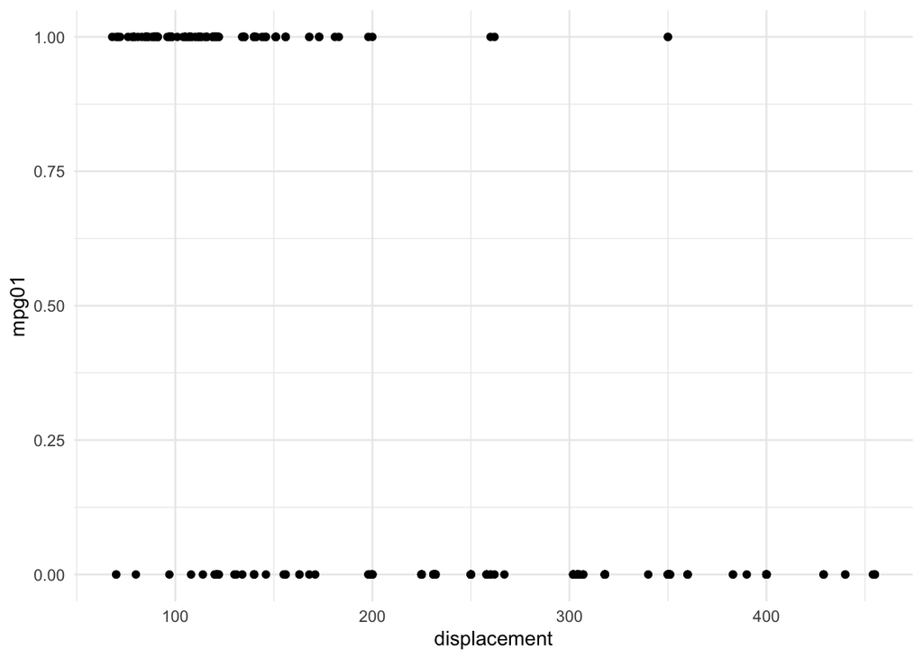

```r
# Scatterplot for mpg01 against displacement
ggplot(Auto, aes(x=displacement, y=mpg01)) + geom_point() + theme_minimal()
```

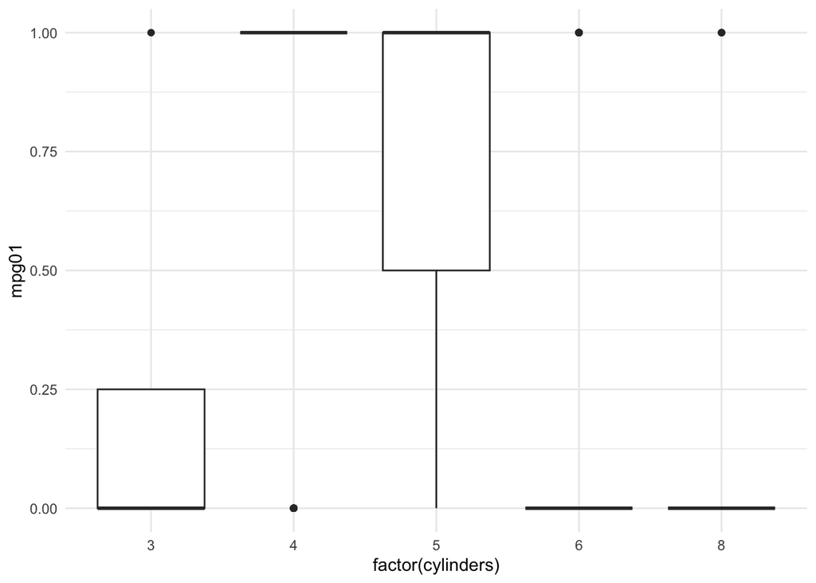

```r
# Boxplot for mpg01 against number of cylinders
ggplot(Auto, aes(x=factor(cylinders), y=mpg01)) + geom_boxplot() + theme_minimal()
```

(3).[2 points] Split the data into a training set and a test set.

```r
set.seed(123)
trainIndex <- createDataPartition(Auto$mpg01, p = .8, list = FALSE, times = 1)
train <- Auto[trainIndex,]
test <- Auto[-trainIndex,]
```

(4).[3 points] Perform LDA on the training data in order to predict `mpg01` using the variables that seemed most associated with `mpg01` in (2). What is the test error of the model obtained?

```r
fit_lda <- lda(mpg01~weight+displacement, data=train)
predictions_lda <- predict(fit_lda, test)$class
table(predictions_lda, test$mpg01)
```

```
##
## predictions_lda  0  1
##               0 28  0
##               1 11 39
```

```r
# Calculate test error
mean(predictions_lda != test$mpg01)
```

```
## [1] 0.1410256
```

(5).[3 points] Perform QDA on the training data in order to predict `mpg01` using the variables that seemed most associated with `mpg01` in (2). What is the test error of the model obtained?

```r
fit_qda <- qda(mpg01~weight+displacement, data=train)
predictions_qda <- predict(fit_qda, test)$class
table(predictions_qda, test$mpg01)
```

```
##
## predictions_qda  0  1
##               0 33  2
##               1  6 37
```

```r
# Calculate test error
mean(predictions_qda != test$mpg01)
```

```
## [1] 0.1025641
```

(6). [3 points] Perform logistic regression on the training data in order to predict `mpg01` using the variables that seemed most associated with `mpg01` in (2). What is the test error of the model obtained?

```r
fit_glm <- glm(mpg01~weight+displacement, data=train, family=binomial)
predictions_glm <- predict(fit_glm, test, type="response") > 0.5
# Calculate test error
mean(predictions_glm != test$mpg01)
```

```
## [1] 0.1282051
```

(7). [3 points] Perform naive Bayes on the training data in order to predict `mpg01` using the variables that seemed most associated with `mpg01` in (2). What is the test error of the model obtained?

```r
fit_nb <- naiveBayes(mpg01~weight+displacement, data=train)
predictions_nb <- predict(fit_nb, test)
# Calculate test error
mean(predictions_nb != test$mpg01)
```

```
## [1] 0.1410256
```

(8). [5 points] Perform KNN on the training data in order to predict `mpg01` using the variables that seemed most associated with `mpg01` in (2). What is the test error of the model obtained? Which value of K seems to perform the best on this data set?

```r
library(class)
# Scale data
train_scaled <- scale(train[, c("weight", "displacement")])
test_scaled <- scale(test[, c("weight", "displacement")], center=attr(train_scaled, "scaled:center"), scale=attr(train_scaled, "scaled:scale"))

# KNN for multiple k values to find the best k
k_values <- seq(1, 20)
errors <- sapply(k_values, function(k) {
  predictions_knn <- knn(train = train_scaled, test = test_scaled, cl = train$mpg01, k = k)
  mean(predictions_knn != test$mpg01)
})
names(errors) <- k_values
print(errors)
```

```
##         1         2         3         4         5         6         7         8
## 0.1025641 0.1410256 0.1025641 0.1153846 0.1282051 0.1153846 0.1153846 0.1153846
##         9        10        11        12        13        14        15        16
## 0.1153846 0.1153846 0.1153846 0.1153846 0.1153846 0.1282051 0.1153846 0.1153846
##        17        18        19        20
## 0.1153846 0.1153846 0.1025641 0.1153846
```

```r
# Find the minimum error and the best k value
min_error <- min(errors)
best_k <- which.min(errors)
cat("The minimum KNN test error is:", min_error, "for k =", k_values[best_k], "\n")
```

```
## The minimum KNN test error is: 0.1025641 for k = 1
```

(9).[3 points] Compare the above models, which models do you think is the best, why?

```
Answer: For my data KNN and QDA are yielding the least errors of 0.1025641. KNN and QDA might be giving you the least error for your dataset due to a few key reasons:
Non-Linear Relationships: Both KNN and QDA excel in capturing non-linear relationships between features and classes. If your data exhibits complex, non-linear patterns, these algorithms can effectively model such structures.
Adaptability to Data Structure: KNN doesn't assume any specific data distribution, making it flexible for various types of data. QDA, on the other hand, allows each class to have its own covariance structure, which is beneficial if the classes in your dataset show different patterns of variability and correlation among features.
Effective Handling of Class Differences: QDA's ability to model different covariance structures for each class makes it particularly effective if your data classes have unique distributions. KNN's reliance on the local neighborhood of data points allows it to adapt to any data distribution, provided the distance metric is meaningful.
Data Characteristics: These methods might outperform others if your dataset is not too large, features are on a similar scale, and the effects of outliers and noise are minimal. KNN and QDA can leverage the inherent characteristics of such data to achieve lower error rates.
In essence, the success of KNN and QDA likely stems from their flexibility and their ability to capture complex patterns in the data without requiring strict assumptions about the underlying data distribution.
```